# Coronavirus SARS-CoV-2 / Covid-19

Time Series of Confirmed, Death and Recovered Cases

Wolfgang Vollmer

2020-03-20

### Source data file: covid_19_data.csv

Data files are provided by **Johns Hopkins University** on GitHub  
https://github.com/CSSEGISandData/COVID-19/tree/master/csse_covid_19_data/csse_covid_19_time_series

# World Map - Total Confirmed for each Country

[interactive chart not shown]

# Top Ten Bar Chart

## Total Confirmed

[interactive chart not shown]

## Total Deaths

[interactive chart not shown]

# Cumulated Cases / Daily Changes over Time

## Worldwide

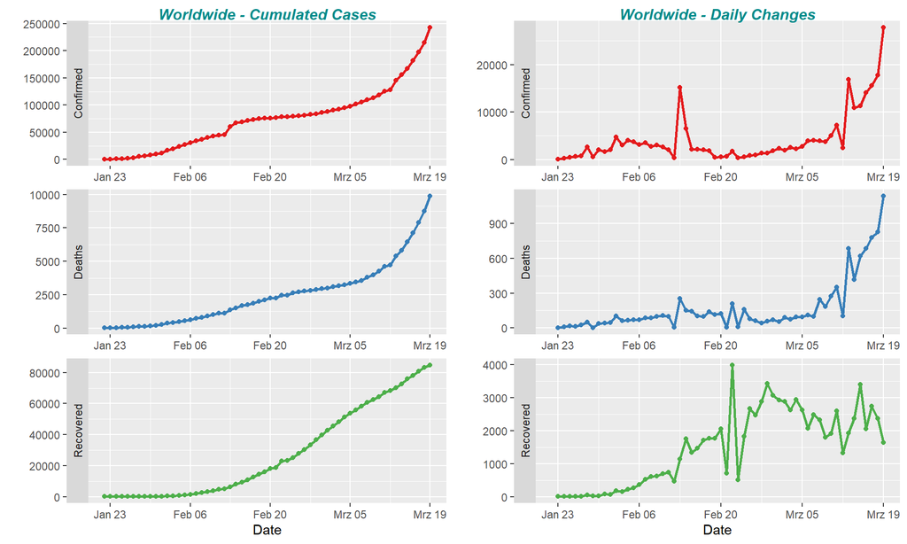

## Selected Countries

### China, South Korea, Austria, Germany, Italy, Spain

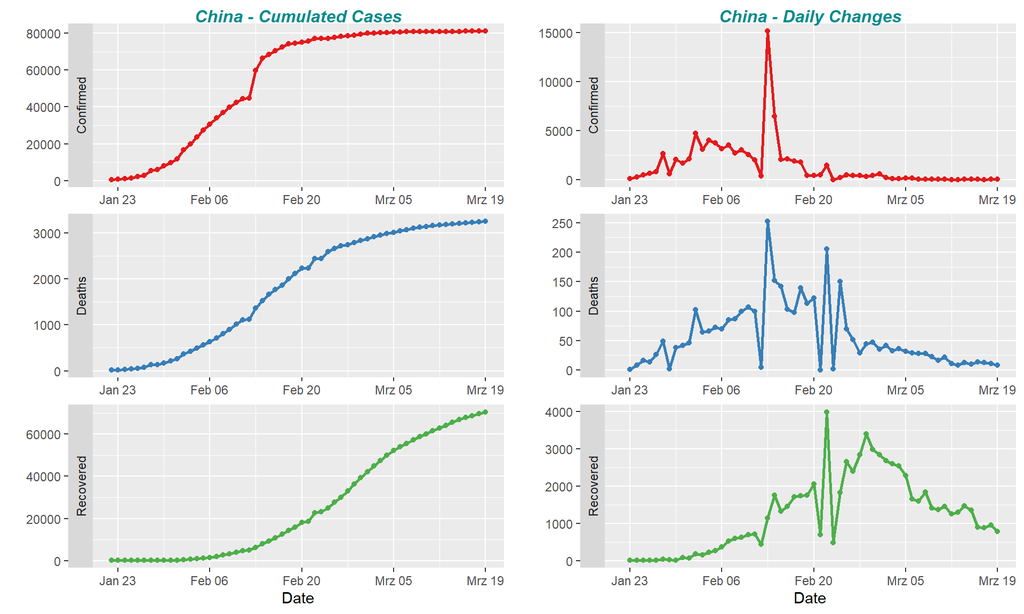

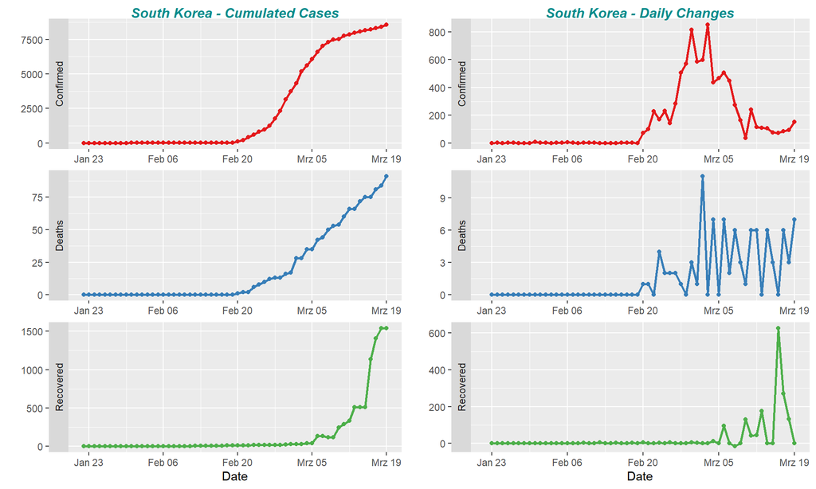

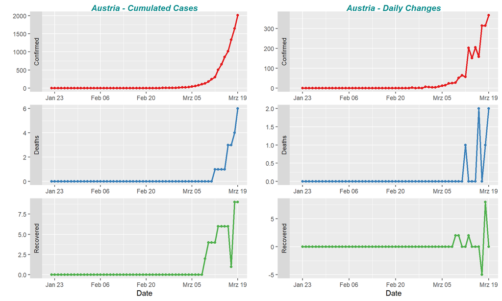

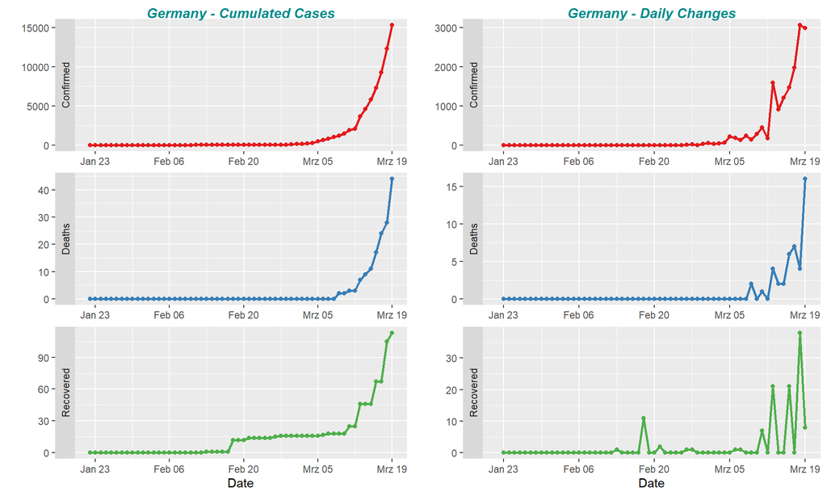

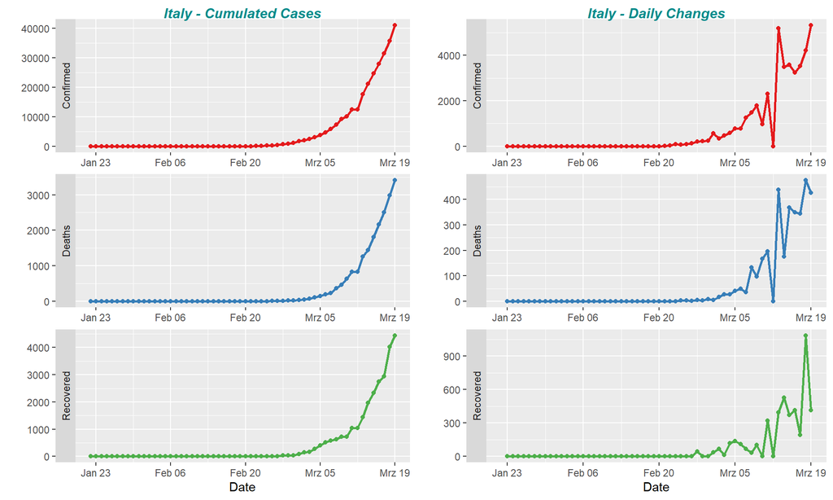

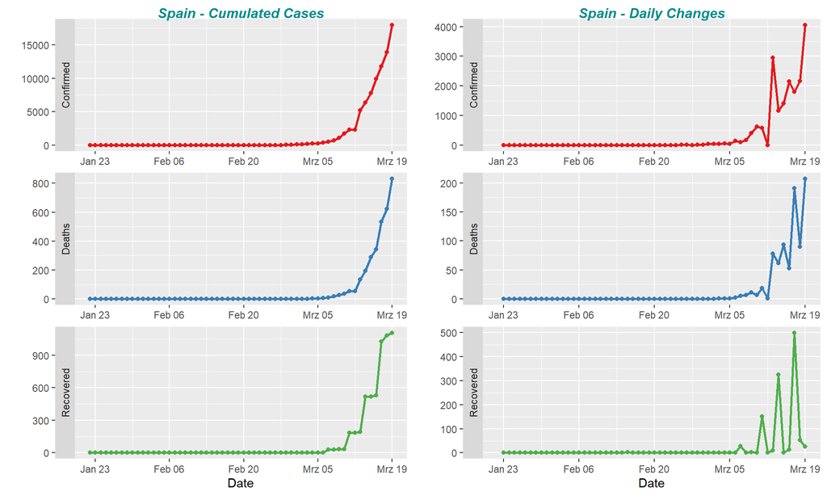

# Doubling Time and Forecasting

### For Selected Countries Austria, Germany, Italy, Spain

Exponential growth over time can be fitted by linear regression if the logarithms of the case numbers is taken. Generally, exponential growth corresponds to linearly growth over time for the log (to any base) data.

The semi-logorithmic plot with base-10 log scale for the Y axis shows functions following an exponential law $y(t) = y_0 * a^{t/\tau}$ as straight lines. The time constant $\tau$ describes the time required for y to increase by one factor of $a$.

If e.g. the confirmed or death cases are growing in $t-days$ by a factor of $10$ the doubling time $T \widehat{=} \tau$ can be calculated with $a \widehat{=} 2$ by

$T[days] = \frac {t[days] * log_{10}(2)} {log_{10}(y(t))-log_{10}(y_0)}$

with

$log_{10}(y(t))-log_{10}(y_0) = = log_{10}(y(t))/y_0) = log_{10}(10*y_0/y_0) = 1$

and doubling time

$T[days] = t[days] * log_{10}(2) \approx t[days] * 0.30$.

For Spain, Italy, Germany we have currently a doubling time $T \approx 9-12 days * 0.3 \approx 2.7 - 4 days !!$.

## Changes over Time and Linear Regression

### Plot Example with log10 scale

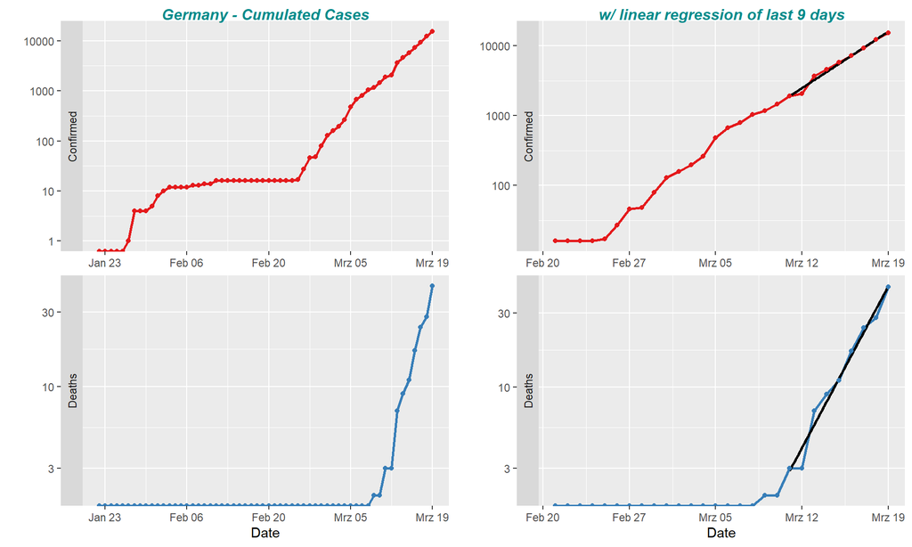

## Comparison of selected Countries

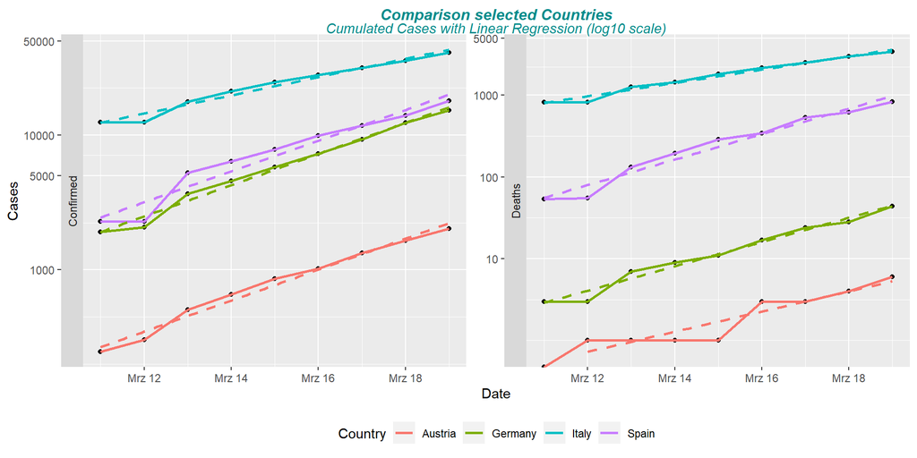

### Plot Example with linear scale showing the extreme forecast increase

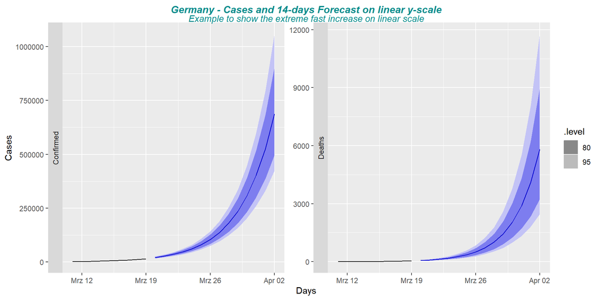

## Doubling Time and Forecast next 14 Days

The forcasted expected cases for the next 14 days are calculated ‘only’ from the linear regression of the logarithmic data are not considering any effects of measures in place. In addition data inaccuracies are not taken into account, especially relevant for the confirmed cases.

Therefore the 14 days forecast is only an indication for the direction of an unchecked exponentiell growth.

Forecast with linear Regression: Doubling Time (days), Expected cases tomorrow and in 14 Days

| Country | Case_Type | T_doubling | forcast_tomorrow | forcast_14days |
| --- | --- | --- | --- | --- |
| Austria | Confirmed | 2.6 | 2891 | 90211 |
| Germany | Confirmed | 2.6 | 20989 | 669727 |
| Italy | Confirmed | 4.4 | 50350 | 382830 |
| Spain | Confirmed | 2.6 | 25945 | 787310 |
| Germany | Deaths | 2.0 | 63 | 5391 |
| Italy | Deaths | 3.7 | 4369 | 50234 |
| Spain | Deaths | 1.9 | 1409 | 150229 |

### Check Forecast Accuracy for last 3 days with Training/Test Data

The Forecast accuracy procedure uses forecast evaluation method three days before today and compares the forecast result for the last three days with the real data of these days. Note: as long as zero deaths are in this time range log(0) will go to infinity, therefore still no linear regression possible.

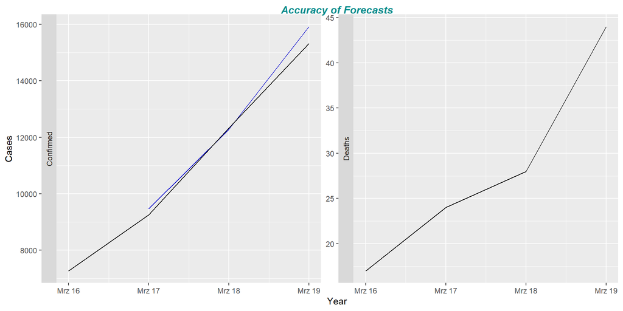

# References

## Data Source

**Johns Hopkins University** data files on GitHub  
https://github.com/CSSEGISandData/COVID-19/tree/master/csse_covid_19_data/csse_covid_19_time_series

- Data files:  
  *time_series_covid_19_confirmed.csv*,  
  *time_series_covid_19_deaths.csv*  
  *time_series_covid_19_recovered.csv*

The data are visualized on their excellent Dashboard  
**Johns Hopkins University Dashboard**  
https://coronavirus.jhu.edu/map.html

Files are also provided on  
**Novel Corona Virus 2019 Dataset - Day level information on covid-19 affected cases**  
https://www.kaggle.com/sudalairajkumar/novel-corona-virus-2019-dataset

Further links:

**WHO Dashboard**  
https://experience.arcgis.com/experience/685d0ace521648f8a5beeeee1b9125cd

**Robert Koch Institut, Germany**  
https://www.rki.de/DE/Content/InfAZ/N/Neuartiges_Coronavirus/Fallzahlen.html?nn=13490888

**Wikipedia - Exponential Growth** https://en.wikipedia.org/wiki/Exponential_growth

## Code Source

Code is based on ideas from https://rpubs.com/TimoBoll/583802